```python
import radarsimpy

print("`RadarSimPy` used in this example is version: " + str(radarsimpy.__version__))
```

```
`RadarSimPy` used in this example is version: 14.0.0
```

# CFAR Detection with RadarSimPy

## Introduction

This notebook demonstrates **RadarSimPy's CFAR (Constant False Alarm Rate) detection capabilities**. RadarSimPy provides built-in implementations of CA-CFAR and OS-CFAR algorithms for adaptive target detection in radar systems.

**What You'll Learn:**

- Use RadarSimPy's CFAR functions for 1D detection
- Configure CA-CFAR (Cell-Averaging CFAR) with `cfar_ca_1d()`
- Configure OS-CFAR (Ordered Statistics CFAR) with `cfar_os_1d()`
- Compare CFAR performance with different parameters
- Apply CFAR to simulated radar range profiles

**Key RadarSimPy Features Demonstrated:**

- **CFAR algorithms**: `cfar_ca_1d()`, `cfar_os_1d()` for 1D detection
- **Flexible parameters**: Guard cells, training cells, false alarm rate
- **Multiple detectors**: Square-law and linear detector types

**Why This Matters:** CFAR enables adaptive thresholding in varying noise environments, improving target detection reliability. RadarSimPy's CFAR functions make it easy to implement and evaluate these algorithms.

### CFAR Background

CFAR (Constant False Alarm Rate) adjusts detection thresholds based on local noise levels:

1. **Estimates background noise** from neighboring cells (training window)
2. **Calculates adaptive threshold** to maintain constant false alarm probability
3. **Compares test cell** against threshold for detection

**RadarSimPy CFAR Algorithms:**

- **CA-CFAR (Cell-Averaging)**: Averages power in training cells
- **OS-CFAR (Ordered Statistics)**: Uses k-th ordered statistic for robustness

**Key Parameters:**

- `guard`: Number of guard cells on each side of test cell
- `trailing`: Number of training cells on each side
- `pfa`: Probability of false alarm (e.g., 1e-4)
- `detector`: "squarelaw" or "linear"
- `k`: Rank for OS-CFAR (typically 3/4 of total training cells)

## Build RadarSimPy Radar Model

Import required modules from RadarSimPy:

```python
import numpy as np
from radarsimpy import Radar, Transmitter, Receiver
```

### Configure Transmitter with RadarSimPy

Define transmitter parameters using RadarSimPy's `Transmitter` class.

#### Define Transmitter Channel

Transmitter channel located at origin:

```python
tx_channel = dict(location=(0, 0, 0))
```

#### Create RadarSimPy Transmitter

Configure FMCW waveform using RadarSimPy's `Transmitter` class:

As shown in the diagram below, `f` and `t` are used to define the waveform modulation. For a linear frequency-modulated continuous waveform (FMCW), it can be specified as `f = [fstart, fend]` and `t = [tstart, tend]`. If `t` is a single number `t = t0`, which is equivalent to `t = [0, t0]`. The bandwidth of the FMCW is `abs(fstart - fend)`. `prp` is the pulse repetition period, and `prp >= (tend - tstart)`.

```
|                       prp
|                  +-----------+
|
|            +---f[1]--->  /            /            /
|                         /            /            /
|                        /            /            /
|                       /            /            /
|                      /            /            /     ...
|                     /            /            /
|                    /            /            /
|                   /            /            /
|      +---f[0]--->/            /            /
|
|                  +-------+
|                 t[0]    t[1]
```

```python
tx = Transmitter(
    f=[24.075e9, 24.175e9],
    t=80e-6,
    tx_power=30,
    prp=100e-6,
    pulses=1,
    channels=[tx_channel],
)
```

### Configure Receiver with RadarSimPy

Define receiver parameters using RadarSimPy's `Receiver` class.

#### Define Receiver Channel

Receiver channel co-located with transmitter:

```python
rx_channel = dict(location=(0, 0, 0))
```

#### Create RadarSimPy Receiver

- `fs` – Sampling rate (sps)
- `noise_figure` – Noise figure (dB)
- `rf_gain` – Total RF gain (dB)
- `load_resistor` – Load resistor to convert power to voltage (Ohm)
- `baseband_gain` – Total baseband gain (dB)

```python
rx = Receiver(
    fs=2e6,
    noise_figure=6,
    rf_gain=20,
    load_resistor=500,
    baseband_gain=30,
    channels=[rx_channel],
)
```

### Assemble Radar System

Combine transmitter and receiver using RadarSimPy's `Radar` class:

```python
radar = Radar(transmitter=tx, receiver=rx)
```

### Define Point Targets

Configure two moving targets with different RCS values:

```python
target_1 = dict(location=(95, 20, 0), speed=(-50, 0, 0), rcs=20, phase=0)
target_2 = dict(location=(30, -5, 0), speed=(-22, 0, 0), rcs=10, phase=0)

targets = [target_1, target_2]
```

## Run RadarSimPy Simulation

Use `sim_radar()` to simulate radar returns from the targets:

```python
from radarsimpy.simulator import sim_radar

data = sim_radar(radar, targets)
timestamp = data["timestamp"]
baseband = data["baseband"] + data["noise"]
```

### Visualize Simulated Baseband

Plot the I/Q baseband signals from RadarSimPy simulation:

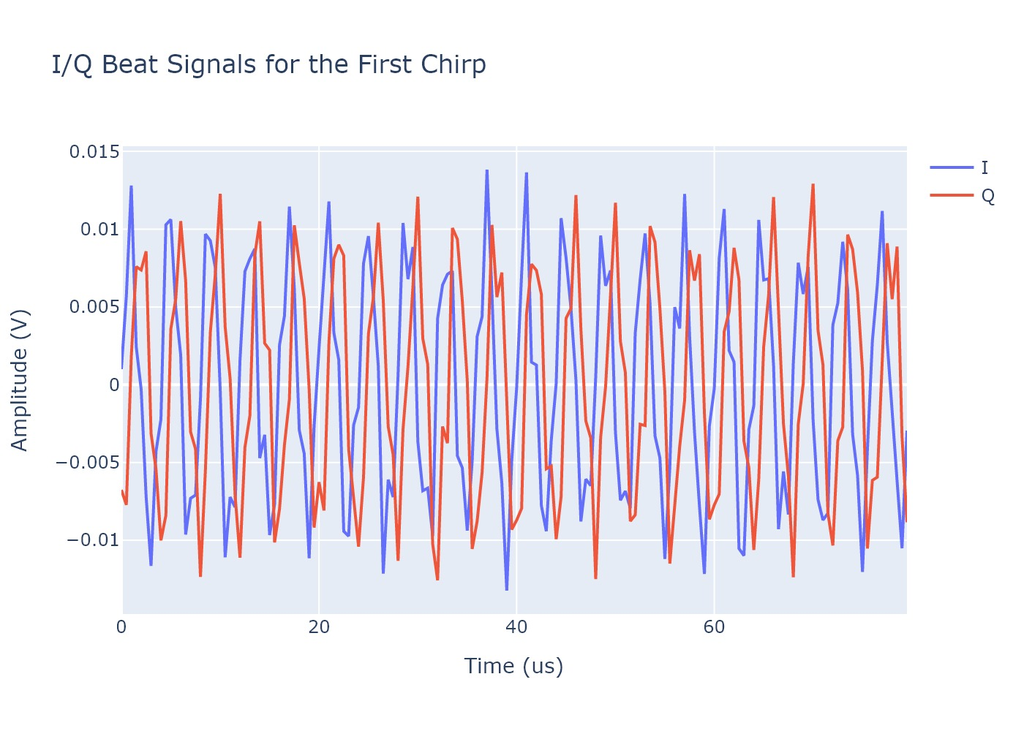

```python
import plotly.graph_objs as go
from IPython.display import Image

fig = go.Figure()
fig.add_trace(
    go.Scatter(
        x=timestamp[0, 0, :] * 1e6,
        y=np.real(baseband[0, 0, :]),
        name="I",
    )
)
fig.add_trace(
    go.Scatter(
        x=timestamp[0, 0, :] * 1e6,
        y=np.imag(baseband[0, 0, :]),
        name="Q",
    )
)
fig.update_layout(
    title="I/Q Beat Signals for the First Chirp",
    yaxis=dict(title="Amplitude (V)"),
    xaxis=dict(title="Time (us)"),
)

# uncomment this to display interactive plot
# fig.show()

# display static image to reduce size on radarsimx.com
img_bytes = fig.to_image(format="jpg", scale=2)
display(Image(img_bytes))
```

## Process with RadarSimPy Functions

### Compute Range Profile

Use RadarSimPy's `range_fft()` to compute range profile:

```python
from scipy import signal
import radarsimpy.processing as proc

range_window = signal.windows.chebwin(radar.sample_prop["samples_per_pulse"], at=60)
range_profile = proc.range_fft(baseband, range_window)
```

### Apply RadarSimPy CFAR Detection

RadarSimPy provides CFAR functions in the `processing` module:

**1D CFAR Functions:**

- `cfar_ca_1d()`: Cell-Averaging CFAR for 1D data
- `cfar_os_1d()`: Ordered Statistics CFAR for 1D data

**2D CFAR Functions** (for range-Doppler maps):

- `cfar_ca_2d()`: Cell-Averaging CFAR for 2D data
- `cfar_os_2d()`: Ordered Statistics CFAR for 2D data

This example demonstrates 1D CFAR on range profiles. For 2D CFAR examples, see the FMCW radar notebooks.

```python
ca_cfar = proc.cfar_ca_1d(
    np.abs(range_profile[0, 0, :]) ** 2,
    guard=2,
    trailing=10,
    pfa=1e-4,
    detector="squarelaw",
)
os_cfar = proc.cfar_os_1d(
    np.abs(range_profile[0, 0, :]) ** 2,
    guard=0,
    trailing=10,
    k=14,
    pfa=1e-4,
    detector="squarelaw",
)
```

### Compare CFAR Algorithms

Visualize range profile with CA-CFAR and OS-CFAR thresholds:

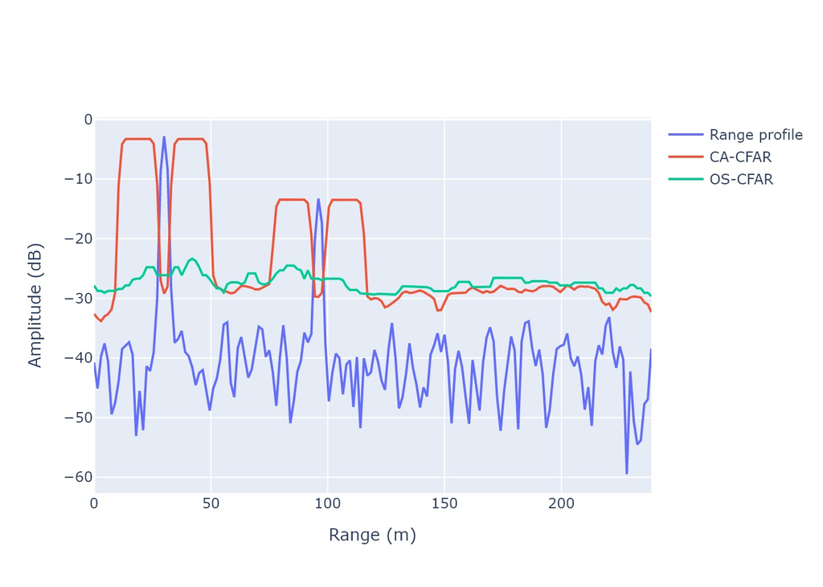

```python
max_range = (
    3e8
    * radar.radar_prop["receiver"].bb_prop["fs"]
    * radar.radar_prop["transmitter"].waveform_prop["pulse_length"]
    / radar.radar_prop["transmitter"].waveform_prop["bandwidth"]
    / 2
)
range_axis = np.linspace(
    0, max_range, radar.sample_prop["samples_per_pulse"], endpoint=False
)

fig = go.Figure()
fig.add_trace(
    go.Scatter(
        x=range_axis,
        y=20 * np.log10(np.abs(range_profile[0, 0, :])),
        name="Range profile",
    )
)
fig.add_trace(go.Scatter(x=range_axis, y=10 * np.log10(ca_cfar), name="CA-CFAR"))
fig.add_trace(go.Scatter(x=range_axis, y=10 * np.log10(os_cfar), name="OS-CFAR"))
fig.update_layout(
    yaxis=dict(title="Amplitude (dB)"),
    xaxis=dict(title="Range (m)"),
)

# uncomment this to display interactive plot
# fig.show()

# display static image to reduce size on radarsimx.com
img_bytes = fig.to_image(format="jpg", scale=2)
display(Image(img_bytes))
```

### Observe CFAR Performance

The plot shows:

**Key Observations:**

- Both CFAR algorithms adapt threshold to local noise level
- OS-CFAR is more robust to interfering targets in training cells
- Guard cells prevent target energy from biasing threshold estimate
- Detection occurs where range profile exceeds CFAR threshold

## Summary and Key Takeaways

### RadarSimPy CFAR Functions Used

This notebook demonstrated:

1. **`cfar_ca_1d()` - Cell-Averaging CFAR**:
   - Averages power in training cells
   - Simple and computationally efficient
   - Good for homogeneous noise environments
2. **`cfar_os_1d()` - Ordered Statistics CFAR**:
   - Uses k-th ranked value from training cells
   - More robust to interfering targets
   - Better for cluttered environments
3. **Key Parameters**:
   - `guard`: Prevents target leakage into training cells
   - `trailing`: Number of cells for noise estimation
   - `pfa`: False alarm probability (1e-4 = 0.01% false alarm rate)
   - `detector`: "squarelaw" for power, "linear" for amplitude

### Experiment Further

1. **Vary CFAR parameters**:
   - Change `guard` and `trailing` cell counts
   - Observe threshold behavior near targets
2. **Test different scenarios**:
   - Add more targets at various ranges
   - Vary target RCS to test detection limits
3. **Compare algorithms**:
   - Try CA-CFAR vs OS-CFAR with close targets
   - Measure detection probability vs false alarm rate
4. **2D CFAR**:
   - Apply `cfar_ca_2d()` or `cfar_os_2d()` to range-Doppler maps
   - See FMCW radar notebooks for examples

### Resources

- RadarSimPy Documentation: https://radarsimx.com
- API Reference: https://radarsimx.github.io/radarsimpy/
- CFAR Functions: `cfar_ca_1d`, `cfar_os_1d`, `cfar_ca_2d`, `cfar_os_2d`